# Exploratory Analysis

Shubham Gupta

July 31, 2016

Clean the global environment

```r
rm(list = ls())
```

Assign colors to global palette

```r
tropical=  c('darkorange', 'dodgerblue', 'hotpink', 'limegreen', 'yellow')
palette(tropical)
par(pch = 21)
```

Look at this link to know more about pch http://www.statmethods.net/advgraphs/parameters.html

Uncomment to install packages  
## —-install_packages, eval=FALSE——————————–  
# install.packages(c(“devtools”,“gplots”))  
# source(“http://www.bioconductor.org/biocLite.R”)  
# biocLite(c(“Biobase”,“org.Hs.eg.db”,“AnnotationDbi”))  
# biocLite(“alyssafrazee/RSkittleBrewer”)  
# install.package(“dendextend”)

### Load libraries

```r
library(gplots)
library(devtools)
library(Biobase)
library(RSkittleBrewer)
library(org.Hs.eg.db)
library(AnnotationDbi)
library(dendextend)
```

## Load the data

```r
con = url("http://bowtie-bio.sourceforge.net/recount/ExpressionSets/bodymap_eset.RData")
load(file=con)
close(con)
bm = bodymap.eset
pdata=pData(bm)
edata=exprs(bm)
fdata = fData(bm)
ls()
```

```
## [1] "bm"           "bodymap.eset" "con"          "edata"
## [5] "fdata"        "pdata"        "tropical"
```

### Understand data

Use str, head, class, summary, dim command to understand properties and nature of data before executing following commands

```r
## ----tables--------------------------------------------------------------
table(pdata$gender)
table(pdata$gender,pdata$race)

## ----summary: You can see that data is skewed by looking at min, max and mean ------
summary(edata)

## ----missing-------------------------------------------------------------
# Use option useNA to include NA's in table
table(pdata$age,useNA="ifany")

# is.na checks for NA values
table(is.na(pdata$age)) # Gives 3 NA values

# Check for other common missing names
sum(pdata$age==" ")
sum(pdata$age==" ", na.rm = TRUE) # So no missing values

# Check genomic data for NAs
sum(is.na(edata))

# Make the distribution of NA's by genes
gene_na = rowSums(is.na(edata))
class(gene_na)
dim(gene_na)
str(gene_na)
head(gene_na)
summary(gene_na)
table(gene_na)

# Make the distribution of NA's by samples
sample_na = rowSums(is.na(edata))
table(sample_na)
```

[output not shown]

Check to make sure dimensions match

```r
dim(fdata)
```

```
## [1] 52580     1
```

```r
dim(pdata)
```

```
## [1] 19  6
```

```r
dim(edata)
```

```
## [1] 52580    19
```

### Graphical view of data

First we make box plot

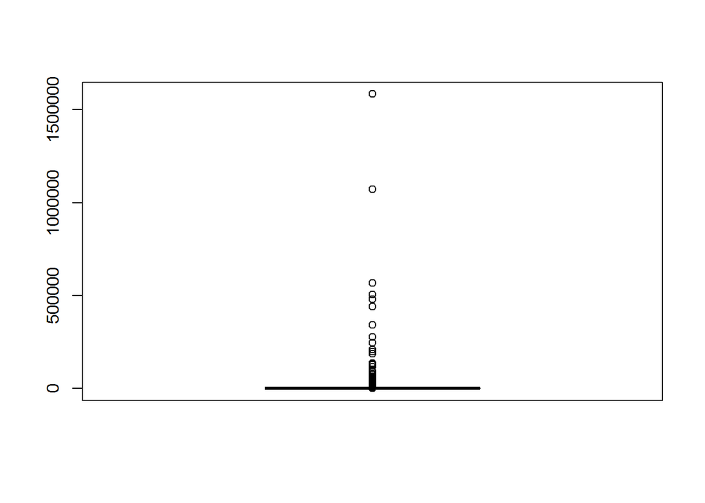

```r
boxplot(edata[,1])
```

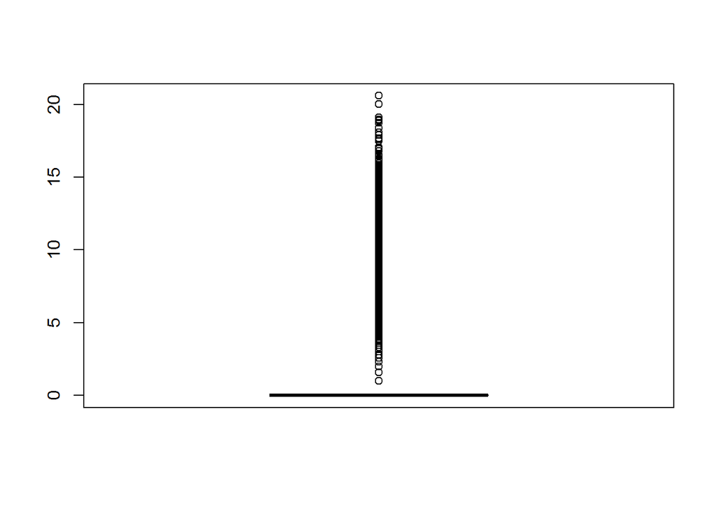

```r
boxplot(log2(edata[,1]+1)) # +1 because some values are zero
```

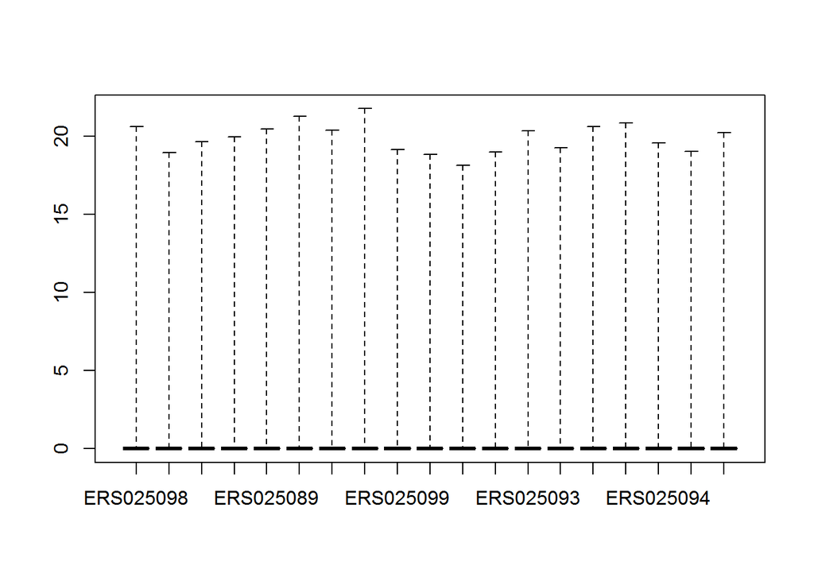

```r
boxplot(log2(edata + 1), col = 2, range = 0)
```

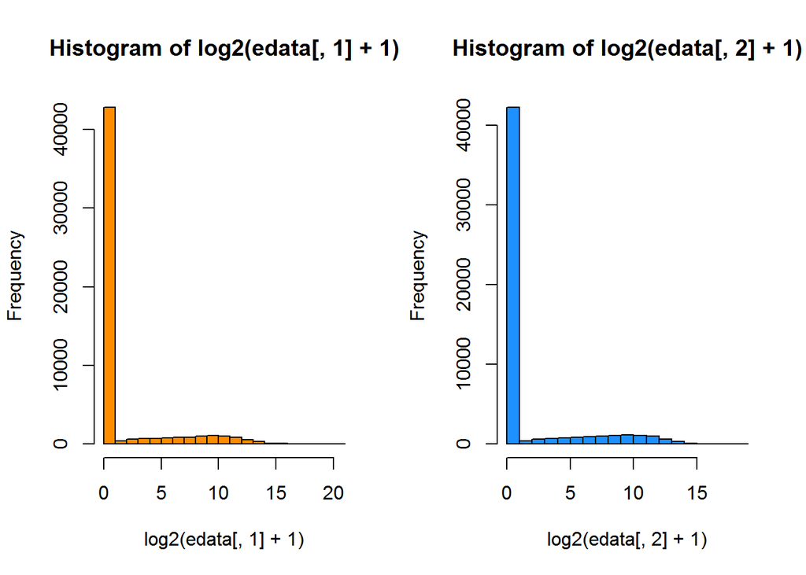

```r
par(mfrow = c(1,2)) # To have 2 plots in one row
hist(log2(edata[,1] + 1), col = 1)
hist(log2(edata[,2] + 1), col = 2)
```

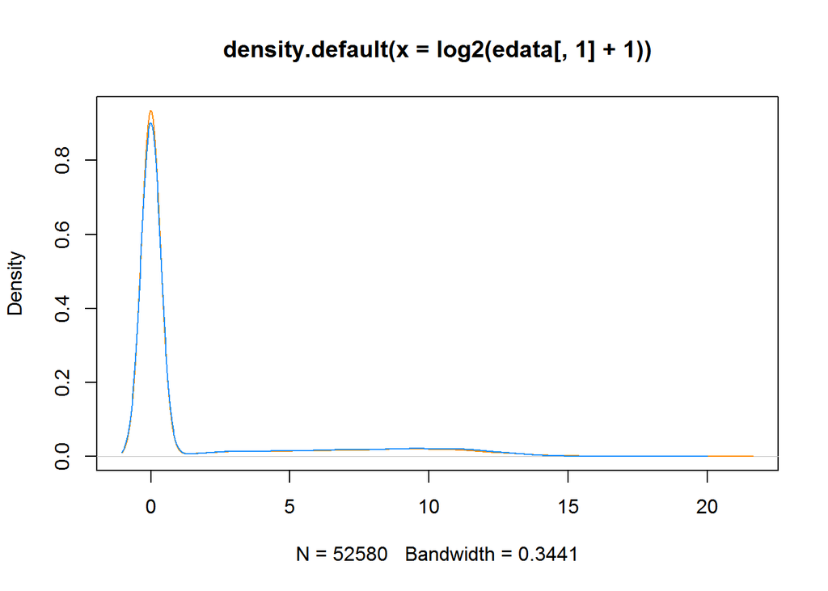

```r
par(mfrow = c(1,1))
plot(density(log2(edata[,1]+1)), col =1)
# lines allows to have overlaying graphs
lines(density(log2(edata[,1]+1)), col =1)
lines(density(log2(edata[,2]+1)), col =2)
```

With lines plot, we can see if there is any artifact when lines don’t overlap and we see a strange bump or something telling that something went awry.

Other types of figures:  
Quantile- quantile plots (QQ plot)  
MA plot

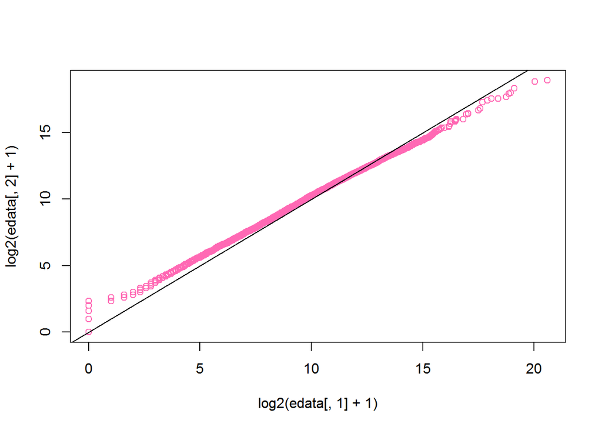

```r
qqplot(log2(edata[,1]+1), log2(edata[,2]+1),col=3)
abline(0,1)
```

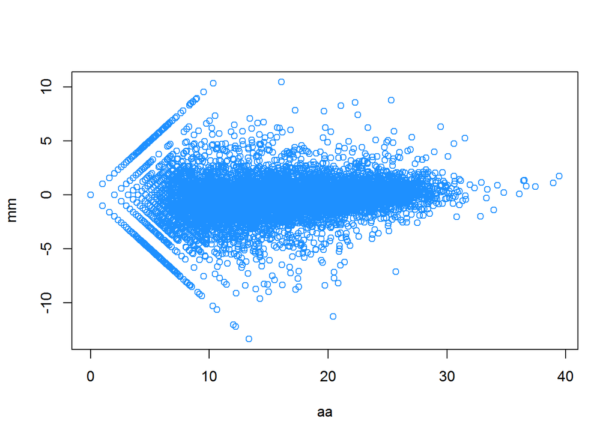

```r
mm = log2(edata[,1]+1) - log2(edata[,2]+1)
aa = log2(edata[,1]+1) + log2(edata[,2]+1)
plot(aa,mm,col=2)
```

Since there are so many low values in edata we need to filter them. Therefore, we need to first transform dataset from matrix to dataframe so that we can apply dplyr filters.

```r
class(edata)
```

```
## [1] "matrix"
```

```r
edata = as.data.frame(edata)
class(edata)
```

```
## [1] "data.frame"
```

```r
filt_edata = filter(edata, rowMeans(edata)>1)
dim(filt_edata)
```

```
## [1] 12276    19
```

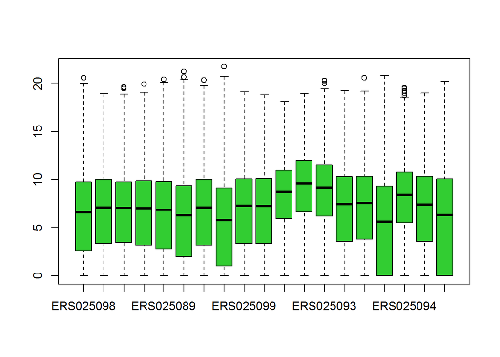

```r
boxplot(as.matrix(log2(filt_edata+1)), col = 4)
```

### Check for consistency

Check for consistency using some external data  
org.Hs.eg.db = Genome wide annotation for Human  
keys must be a character so we need to do casting

```r
class(fdata[,1])
```

```
## [1] "factor"
```

```r
aeid = as.character(fdata[,1])
# Extract chromosome information from ENSEMBL ids
chr = AnnotationDbi::select(org.Hs.eg.db,keys=aeid,keytype="ENSEMBL",columns="CHR")
class(chr)
```

```
## [1] "data.frame"
```

```r
dim(chr)
```

```
## [1] 52633     2
```

```r
dim(fdata)
```

```
## [1] 52580     1
```

```r
colnames(chr)
```

```
## [1] "ENSEMBL" "CHR"
```

```r
head(chr)
```

```
##           ENSEMBL CHR
## 1 ENSG00000000003   X
## 2 ENSG00000000005   X
## 3 ENSG00000000419  20
## 4 ENSG00000000457   1
## 5 ENSG00000000460   1
## 6 ENSG00000000938   1
```

```r
# Take non-duplicated chromsomes
chr = chr[!duplicated(chr[,1]),]
dim(chr)
```

```
## [1] 52580     2
```

```r
all(chr[,1] == rownames(fdata))
```

```
## [1] TRUE
```

```r
all(chr[,1] == rownames(edata))
```

```
## [1] TRUE
```

## Data transformation

Log is good transformation variable for highly skewed data  
We take log2 because when we compare them, we subtract and now if we see value increased by 1 means value is doubled.

```r
head(edata,n = 5)
```

```
##                 ERS025098 ERS025092 ERS025085 ERS025088 ERS025089
## ENSG00000000003      1354       216       215       924       725
## ENSG00000000005       712       134         4      1495       119
## ENSG00000000419       450       547       516       529       808
## ENSG00000000457       188       368       196       386       156
## ENSG00000000460        66        29         1        26        11
##                 ERS025082 ERS025081 ERS025096 ERS025099 ERS025086
## ENSG00000000003       125       796      1954       815       249
## ENSG00000000005        20         7         0         0        16
## ENSG00000000419       680       744       369       636       486
## ENSG00000000457       259       436       288       187       553
## ENSG00000000460         9        25        42        12        22
##                 ERS025084 ERS025087 ERS025093 ERS025083 ERS025095
## ENSG00000000003      4614      6548      5030      1450       781
## ENSG00000000005       975       923       696        15        24
## ENSG00000000419      1200      2823      2159       933       870
## ENSG00000000457      1543      1194       876       655       862
## ENSG00000000460       213        80        57        13        78
##                 ERS025097 ERS025094 ERS025090 ERS025091
## ENSG00000000003        69      1888       983         3
## ENSG00000000005         0        20         4         0
## ENSG00000000419       621      1026      1185       765
## ENSG00000000457       242       569       609       782
## ENSG00000000460        17       351        46        73
```

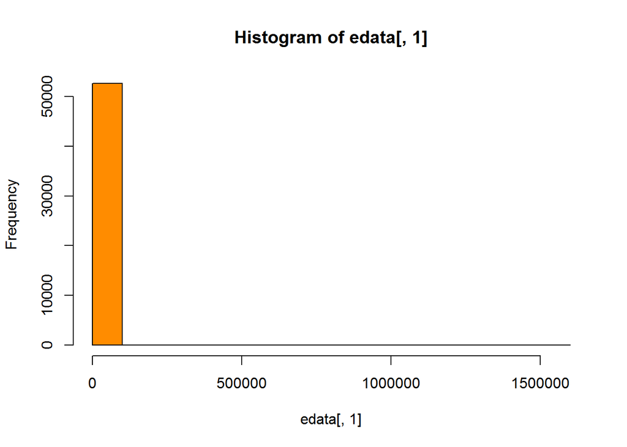

```r
hist(edata[,1], col =6)
```

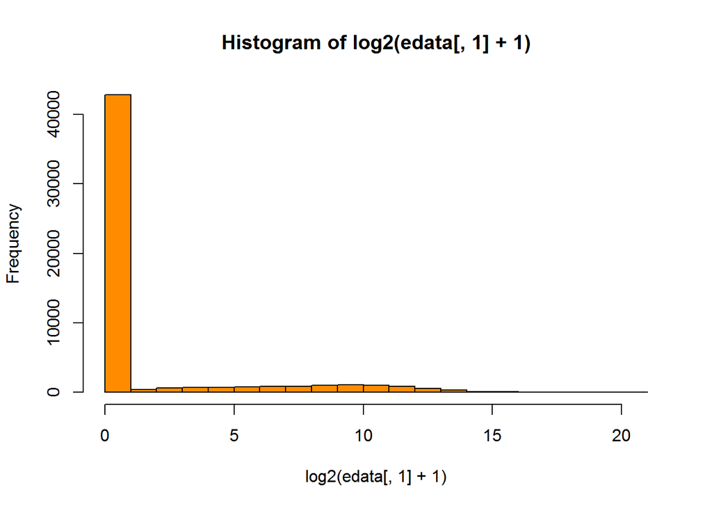

```r
hist(log2(edata[,1]+1), col =6)
```

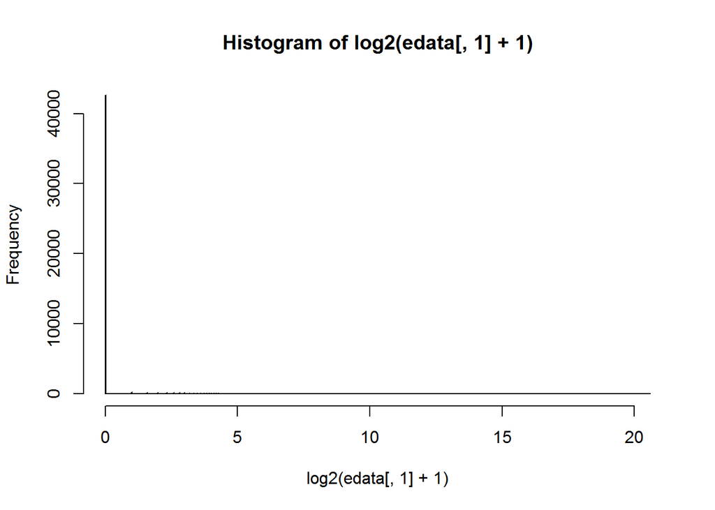

```r
hist(log2(edata[,1]+1), col =6, breaks = 1000)
```

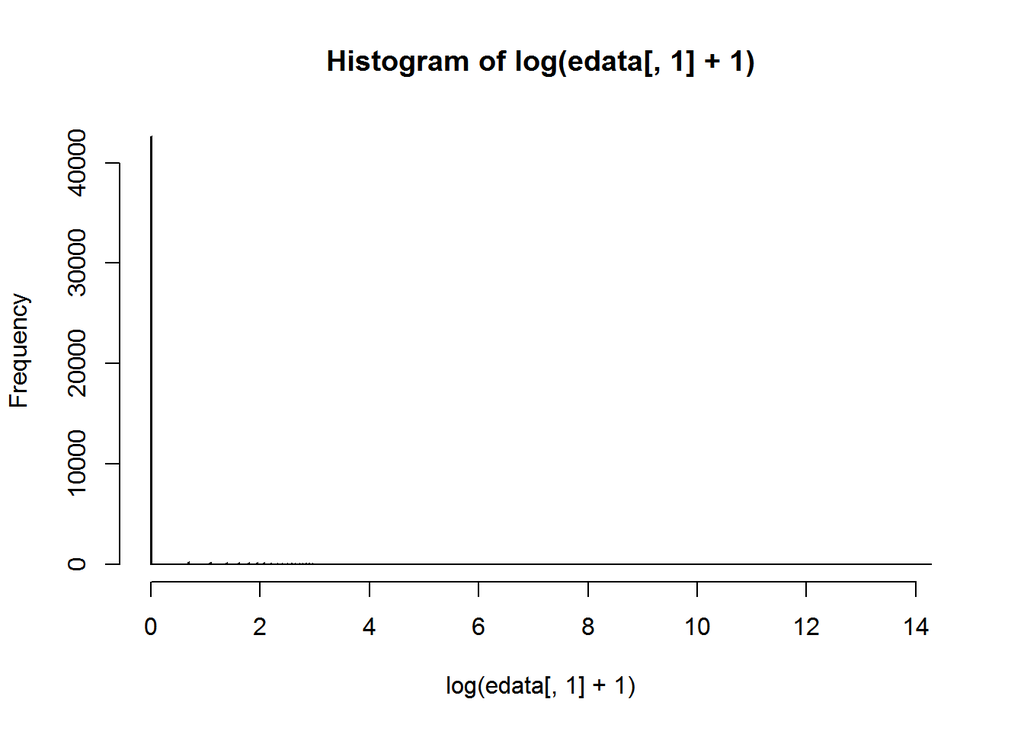

```r
hist(log(edata[,1]+1), col =6, breaks = 1000)
```

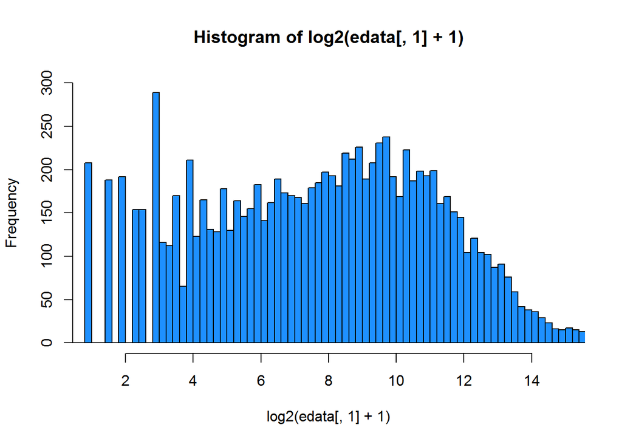

```r
#Zoom in to ignore zeros
hist(log2(edata[,1]+1), col =2, breaks = 100, xlim = c(1,15), ylim = c(0,300))
```

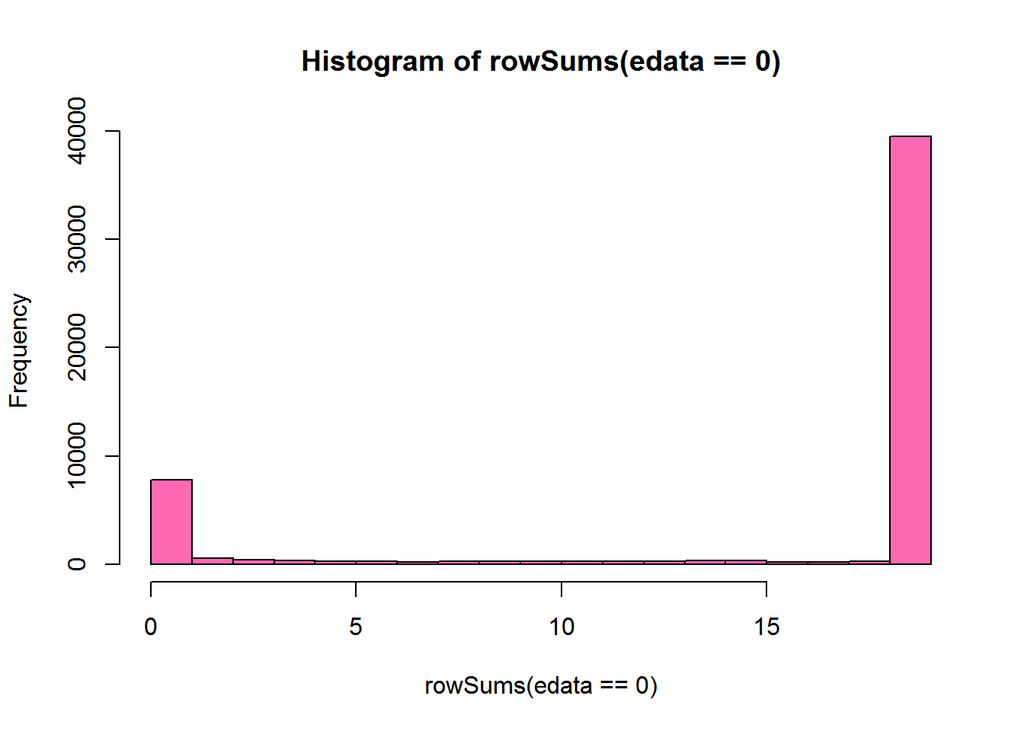

```r
hist(rowSums(edata==0),col =3)
```

rowSums sums along the row, so it combines TRUE value for all 19 columns. And from the graph we can see that there are many rows(genes) which has value(expression value) = 0 in all columns(patients)

Now we remove the zero values.Filter low expressed genes.

```r
low_genes  = rowMeans(as.matrix(edata))<5;
table(low_genes)
```

```
## low_genes
## FALSE  TRUE
## 11413 41167
```

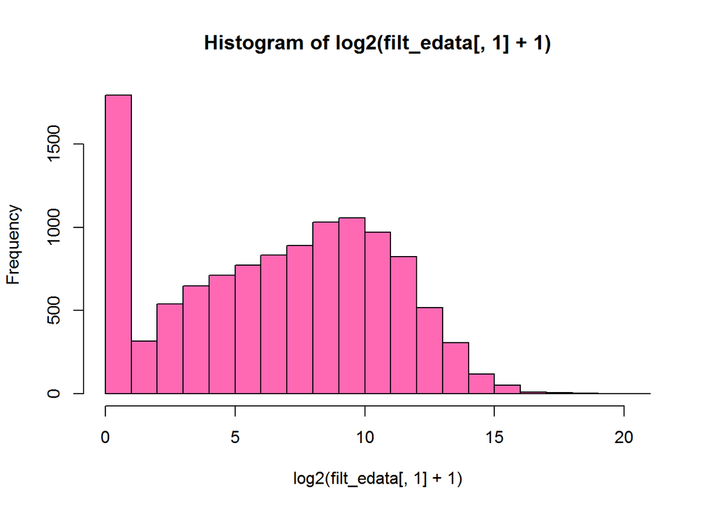

```r
filt_edata = filter(edata, !low_genes)
hist(log2(filt_edata[,1]+1), col = 3)
```

```r
low_genes2  = rowMedians(as.matrix(edata))<5;
table(low_genes2)
```

```
## low_genes2
## FALSE  TRUE
##  9846 42734
```

```r
table(low_genes2, low_genes)
```

```
##           low_genes
## low_genes2 FALSE  TRUE
##      FALSE  9844     2
##      TRUE   1569 41165
```

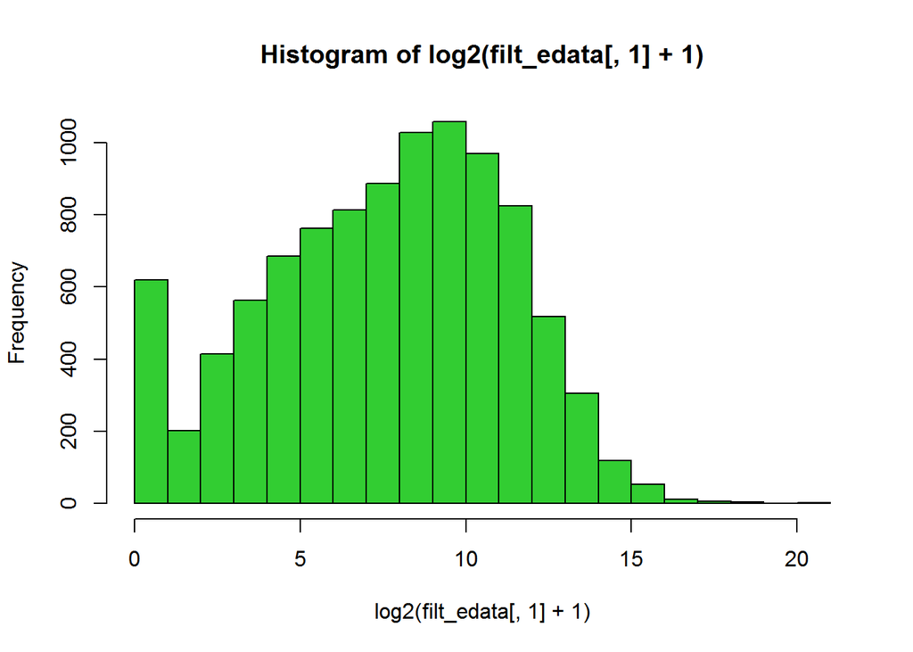

```r
filt_edata = filter(edata, !low_genes2)
hist(log2(filt_edata[,1]+1), col = 4)
```

```
##  setting  value
##  version  R version 3.3.1 (2016-06-21)
##  system   x86_64, mingw32
##  ui       RTerm
##  language (EN)
##  collate  English_United States.1252
##  tz       America/New_York
##  date     2016-07-31
```

```
## Packages ------------------------------------------------------------------
```

[output not shown]

[output cut: 15 more lines]

[output not shown]